# IE48A-Final

Merve Gulsum Kiratli

9/14/2020

# Part1 : Short and Simple

1. What is your opinion about the COVID analyses and the way countries are compared to each other? What are the weaknesses in comparison methods and how can they be improved?

A susceptible-infected-removed (SIR) model is based upon the well-known susceptible-infected-removed (SIR) model with the difference that a total population is not defined or kept constant per se and the number of susceptible individuals does not decline monotonically. But there are some problems. For example, I can understand how the spread will decrease when people stay away from each other. What if the majority of people were isolated from each other, but if other people occasionally went to public areas such as the market or school? In addition, if we were able to detect and isolate the cases, how would this process continue? What if we could reduce the number of people who were not noticed positive because they had no health complaints and were not tested? How does the transitivity between different communities affect this situation? Or if people don’t go out for a while and then stop taking precautions? If these question marks are resolved, major problems in COVID-19 analyzes will be solved.

2. What is your exploratory data analysis workflow? Suppose you are given a data set and a research question. Where do you start? How do you proceed? For instance, you are given the task to distribute funds from donations to public welfare projects in a wide range of subjects (e.g. education, gender equality, poverty, job creation, healthcare) with the objective of maximum positive impact on the society in general. Assume you have almost all the data you require. How do you measure impact? How do you form performance measures? What makes you think you find an interesting angle? Would you present an argument for a policy that you are more inclined to (e.g. suppose you are more inclined to allocate budget to fix gender inequality than affordable healthcare) or would you just present what data says? In other words, would the (honest) title of your presentation be “Gender Inequality -The Most Important Social Problem Backed by Data” or “Pain Points in Our Society and Optimal Budget Allocation”?

My workflow can be broken down into six components:

- Define the problem
- Gather the data
- Explore the data
- Model with the data
- Evaluate the model
- Answer the problem

First of all, I will start this process by exploring data with some techniques. Then I will check the anomalies and outliers in the data. After cleaning data, I will use some visualization techniques to understand relations between featurers. Then It is time to manipulate the data in order to get some answers for this research questions. Finally, machine learning algorithms can help me go a step further into getting insights and predicting future trends.

For this given task, it is assumed that we have all data for distribute funds from donations to public welfare projects. After we applied the process that I mentioned above, while we are modeling machine algorithms we can extract important features for public welfare (output). So this feature importance indexes can be used as impact of these subjects. If I am able to find a feature that effect social welfare dominantly, then this can be interesting angle for this task.

According to real data outputs , I choose “Pain Points in Our Society and Optimal Budget Allocation”.

3. If you had to plot a single graph using the starwars data what would it be? Why? Make your argument,actually code the plot and provide the output.

```r
library(dplyr)
```

```r
library(tidyr)
library(ggplot2)
starwars%>% glimpse()
```

```
## Rows: 87
## Columns: 14
## $ name       <chr> "Luke Skywalker", "C-3PO", "R2-D2", "Darth Vader", "Leia...
## $ height     <int> 172, 167, 96, 202, 150, 178, 165, 97, 183, 182, 188, 180...
## $ mass       <dbl> 77.0, 75.0, 32.0, 136.0, 49.0, 120.0, 75.0, 32.0, 84.0, ...
## $ hair_color <chr> "blond", NA, NA, "none", "brown", "brown, grey", "brown"...
## $ skin_color <chr> "fair", "gold", "white, blue", "white", "light", "light"...
## $ eye_color  <chr> "blue", "yellow", "red", "yellow", "brown", "blue", "blu...
## $ birth_year <dbl> 19.0, 112.0, 33.0, 41.9, 19.0, 52.0, 47.0, NA, 24.0, 57....
## $ sex        <chr> "male", "none", "none", "male", "female", "male", "femal...
## $ gender     <chr> "masculine", "masculine", "masculine", "masculine", "fem...
## $ homeworld  <chr> "Tatooine", "Tatooine", "Naboo", "Tatooine", "Alderaan",...
## $ species    <chr> "Human", "Droid", "Droid", "Human", "Human", "Human", "H...
## $ films      <list> [<"The Empire Strikes Back", "Revenge of the Sith", "Re...
## $ vehicles   <list> [<"Snowspeeder", "Imperial Speeder Bike">, <>, <>, <>, ...
## $ starships  <list> [<"X-wing", "Imperial shuttle">, <>, <>, "TIE Advanced ...
```

Geom_point was used to see the distribution of the mass and height of names according to gender.

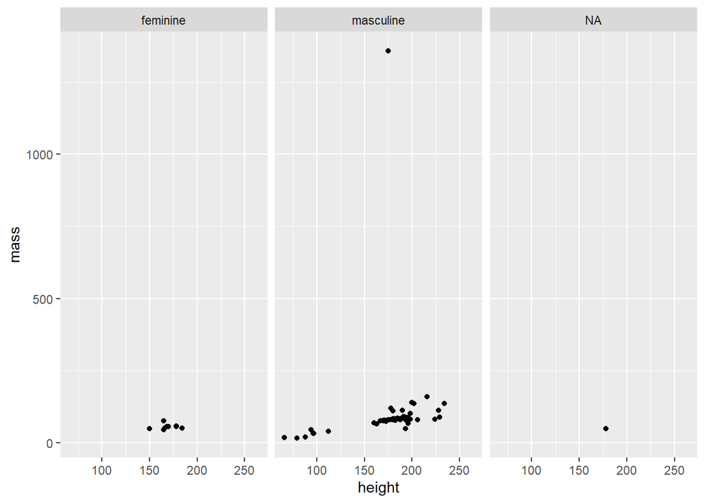

```r
ggplot(data = starwars, mapping = aes(x = height, y = mass)) +
  geom_point() +
  facet_grid(. ~ gender)
```

# Part2 : Extending Your Group Project

In our group data, 81 provinces of Turkey contain information about first-hand and second-hand home price indexes. Migration movements in cities, economic movements throughout the country and some changes in cities, such as opening factories, are some of the factors that affect home price index data.

First, the packages required for group data were loaded and initial steps were applied to the data.

```r
library(tidyverse)
library(lubridate)
library(dplyr)
library(cluster)
library(factoextra)
```

```r
library(sp)
library(openxlsx)
library(mapproj)
library(gridExtra)
library(ggthemes)
library(tseries)
library(forecast)
library(readxl)
library(data.table)
library(ggplot2)
library(car)
evds = read.csv("https://raw.githubusercontent.com/pjournal/boun01g-hisrustu/gh-pages/housing_data_EVDS.csv")

url <- "https://raw.githubusercontent.com/pjournal/boun01g-hisrustu/gh-pages/TUR_1_sp.rds"

TUR <- readRDS(url(url, method="libcurl"))

TUR_fixed <- fortify(TUR)
convertName<-function(data,handLabel){
  data <- gsub(".*- (.+) -.*", "\\1", data)
  data <- gsub("\u008d", "i", data)
  data <- gsub("€", "C", data)
  data <- gsub("ž", "S", data)
  data <- gsub("Ÿ", "s", data)
  data <- gsub("\u0081", "u", data)
  data <- gsub("˜", "I", data)
  data <- gsub("§", "g", data)
  data <- gsub("”", "o", data)
  data <- paste(handLabel, data, sep="_")
  return(data)
}

datainfo = evds[c(92:1080),]
cityNames<-evds[c(95:258),2]
firstHandCityNames<-cityNames[c(1:82)]
secondHandCityNames<-cityNames[c(83:164)]
evds = evds[c(1:91),]
firstHandCityNames<-convertName(firstHandCityNames,"F")
secondHandCityNames<-convertName(secondHandCityNames,"S")
allNames= c("Tarih",firstHandCityNames,secondHandCityNames)
names(evds)<-allNames

for(i in c(1:165)){
  evds[,i] <- gsub(",","",evds[,i])
}
evds[, c(2:165)] <- sapply(evds[, c(2:165)], as.numeric)
names(evds)[1] = "Date"

evds$Date = paste(evds$Date,"01",sep="-")
evds = evds %>%
  mutate(Date=as.Date(Date, format="%Y-%m-%d")) %>%
  mutate(Year=year(Date), Month=month(Date))

find_season <- function(mon){
  season = NULL

  if(between(mon, 3, 5)){
    season = "Spring"
  } else if(between(mon, 6, 8)){
    season = "Summer"
  } else if(between(mon, 9, 11)){
    season = "Fall"
  } else{
    season = "Winter"
  }

  return(season)
}
evds$Season = sapply(evds$Month, find_season)

evds[,c(2)] - rowSums(evds[,c(3:83)], na.rm = FALSE)
```

```
##  [1]  0  0 NA  0  0  0  0  0  0  0  0  0  0 NA  0  0  0  0  0  0  0  0  0  0  0
## [26]  0  0  0  0  0  0  0  0  0  0  0  0 NA  0  0 NA  0 NA  0  0  0  0  0  0  0
## [51]  0  0  0 NA  0  0  0  0  0  0  0  0  0  0  0  0  0  0  0  0  0  0  0  0 NA
## [76]  0  0  0  0  0  0  0  0  0  0  0  0  0  0  0  0
```

```r
evds[,c(2)] - rowSums(evds[,c(3:83)], na.rm = TRUE)
```

```
##  [1] 0 0 0 0 0 0 0 0 0 0 0 0 0 0 0 0 0 0 0 0 0 0 0 0 0 0 0 0 0 0 0 0 0 0 0 0 0 0
## [39] 0 0 0 0 0 0 0 0 0 0 0 0 0 0 0 0 0 0 0 0 0 0 0 0 0 0 0 0 0 0 0 0 0 0 0 0 0 0
## [77] 0 0 0 0 0 0 0 0 0 0 0 0 0 0 0
```

```r
evds[is.na(evds)] <- 0
```

```r
Akdeniz_Bolge<-evds[,c("Year", "Month", "Season","F_Antalya", "F_Mersin", "F_Adana","F_Hatay")]
Ege_Bolge<-evds[,c("Year", "Month", "Season","F_Izmir", "F_Aydin", "F_Mugla")]
Marmara_Bolge<-evds[,c("Year", "Month", "Season","F_Edirne", "F_Tekirdag", "F_Istanbul", "F_Kocaeli", "F_Yalova", "F_Bursa", "F_Balikesir", "F_Canakkale")]

Akdeniz<-Akdeniz_Bolge %>%  group_by( Year)%>% summarize(Mean = sum(F_Antalya, F_Mersin, F_Adana, F_Hatay)/4)
colnames(Akdeniz)<-c("Year", "Mean of Akdeniz")


Ege<- Ege_Bolge %>% group_by(Year) %>% summarise(Mean = sum(F_Izmir, F_Aydin, F_Mugla)/3)
colnames(Ege)<-c("Year", "Mean of Ege")


Marmara<- Marmara_Bolge %>% group_by(Year) %>% summarise(Mean = sum(F_Edirne, F_Tekirdag, F_Istanbul, F_Kocaeli, F_Yalova, F_Bursa, F_Balikesir, F_Canakkale)/8)
colnames(Marmara)<-c("Year", "Mean of Marmara")


df1<-data.frame(Marmara, Ege[,2], Akdeniz[,2])
df1
```

```
##   Year Mean.of.Marmara Mean.of.Ege Mean.of.Akdeniz
## 1 2013       21443.625   14535.667        13574.00
## 2 2014       21355.875   14870.333        13682.00
## 3 2015       23611.875   15845.333        14867.50
## 4 2016       23568.875   17357.333        15406.25
## 5 2017       25391.375   18862.000        16369.50
## 6 2018       24547.125   18214.333        16731.75
## 7 2019       19114.875   14202.333        13086.50
## 8 2020        9761.625    8204.333         7154.50
```

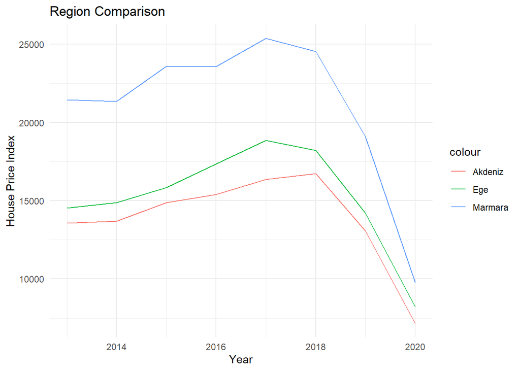

```r
ggplot(df1, aes(x=Year)) +
  geom_line(aes(y=Mean.of.Marmara, color="Marmara")) +
  geom_line(aes(y=Mean.of.Ege, color="Ege")) +
  geom_line(aes(y=Mean.of.Akdeniz, color="Akdeniz")) +
 theme_minimal() +
  ggtitle("Region Comparison") +
  labs(x = "Year", y = "House Price Index")
```